# Approaches to biomedical knowledge

The Kolmogorov–Smirnov Test

Peter Robinson

Free University Berlin

## The Kolmogorov–Smirnov (KS) test

**Warning**

These slides are intended to provide extra background to understand the GSEA algorithm presented in lecture #2 and do not intend to provide a full account of the KS test.

Suppose that we have an i.i.d. sample $X_1,\ldots , X_n$ with some unknown distribution $\mathbb{P}$ and we would like to test the hypothesis that $\mathbb{P}$ is equal to a particular distribution $\mathbb{P}_0$, i.e. decide between the following hypotheses:

$$\begin{aligned}
H_0 : \mathbb{P} &= \mathbb{P}_0 \\
H_1 : \mathbb{P} & \neq \mathbb{P}_0 \\
\end{aligned}$$

The KS test is a non-parametric<sup>1</sup> method for comparing probability distributions and checking if two samples differ significantly.

[^1]: i.e., it does not assume any specific distribution form

## The question

- We have a sample $x_1, \dots, x_n$.
- **One-sample question:** could it have come from a specified distribution $F$ (for example $N(0,1)$)?
- **Two-sample question:** could two samples come from the *same* distribution?
- Chi-square tests require binning the data. The KS test works on the raw values, with no binning.
- Both questions are answered by comparing **cumulative distribution functions**.

## The empirical CDF (ECDF)

The ECDF is the fraction of $n$ **ordered** observations at or below $x$:

$$F_n(x) = \frac{1}{n} \sum_{i=1}^{n} \mathbf{1}\{x_i \le x\}$$

It is a step function that jumps by $1/n$ at each data point and rises from 0 to 1.

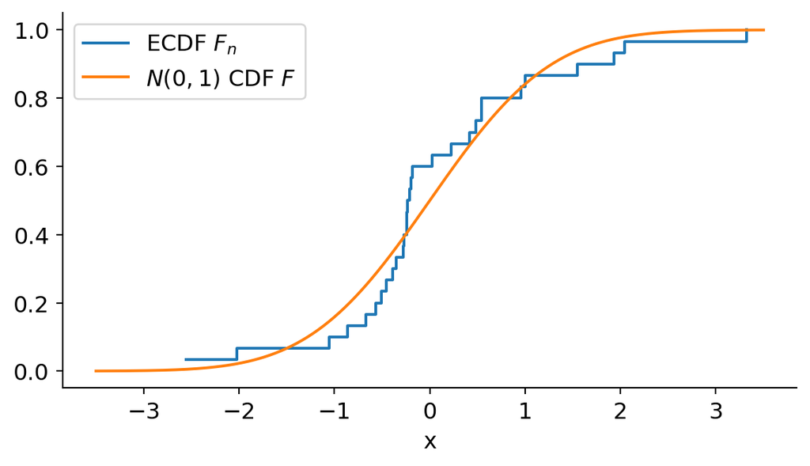

## The test statistic

$$D_n = \sup_x \left| F_n(x) - F(x) \right|$$

$D_n$ is the **largest vertical gap** between the ECDF and the hypothesized CDF.

- $D_n$ is always between 0 and 1.
- Small $D_n$: the sample looks like $F$.
- Large $D_n$: the sample is far from $F$, so we reject.
- The largest gap can occur **anywhere** along the distribution.

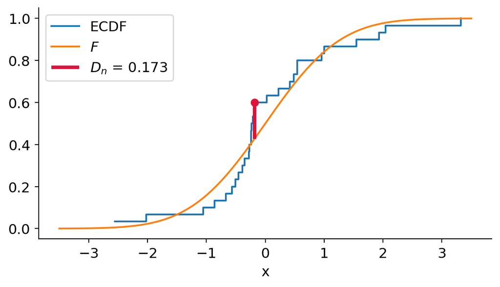

## Computing $D_n$ by hand

The ECDF is a step function and $F$ is continuous, so the largest gap occurs at a data point, either just **before** or just **after** a jump. We must check **both**:

- **Just after the jump** (ECDF is above $F$): $D_n^+ = \max_i \left(\tfrac{i}{n} - F(x_{(i)})\right)$
- **Just before the jump** (ECDF is below $F$): $D_n^- = \max_i \left(F(x_{(i)}) - \tfrac{i-1}{n}\right)$

$$D_n = \max(D_n^+,\, D_n^-)$$

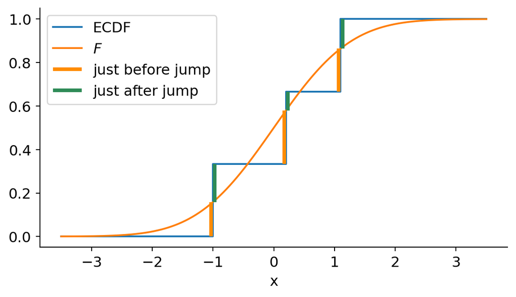

## What would $D_n$ look like if $H_0$ were true?

Simulate 10,000 samples of size $n = 30$ from $N(0,1)$ and compute $D_n$ for each:

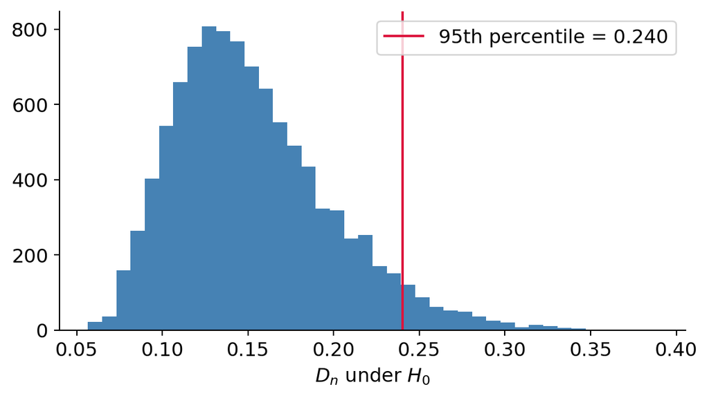

The p-value is the fraction of this null distribution at least as large as the observed $D_n$.

## How $D_n$ scales with $n$

Under $H_0$, $D_n$ shrinks like $1/\sqrt{n}$.<sup>1</sup> The scaled quantity $\sqrt{n}\, D_n$ has (approximately) the **same distribution for every $n$**. This is the Kolmogorov distribution.

```
n=  30  95th pct of D_n = 0.241   95th pct of sqrt(n)*D_n = 1.322
n= 120  95th pct of D_n = 0.122   95th pct of sqrt(n)*D_n = 1.338
```

At $\alpha = 0.05$, the asymptotic critical value is

$$D_{n,\,0.05} \approx \frac{1.36}{\sqrt{n}}$$

- In practice, software computes the p-value (`scipy.stats.kstest` or R’s `ks.test`).
[^2]: (the ECDF at any point is an average of $n$ indicators, so its spread is of order $1/\sqrt{n}$)

## Under an alternative

Sample from $N(0.5, 1)$ and test against $N(0,1)$:

```
KstestResult(statistic=np.float64(0.4050996543021373), pvalue=np.float64(5.826477046905052e-05), statistic_location=np.float64(0.35427336756472355), statistic_sign=np.int8(-1))
```

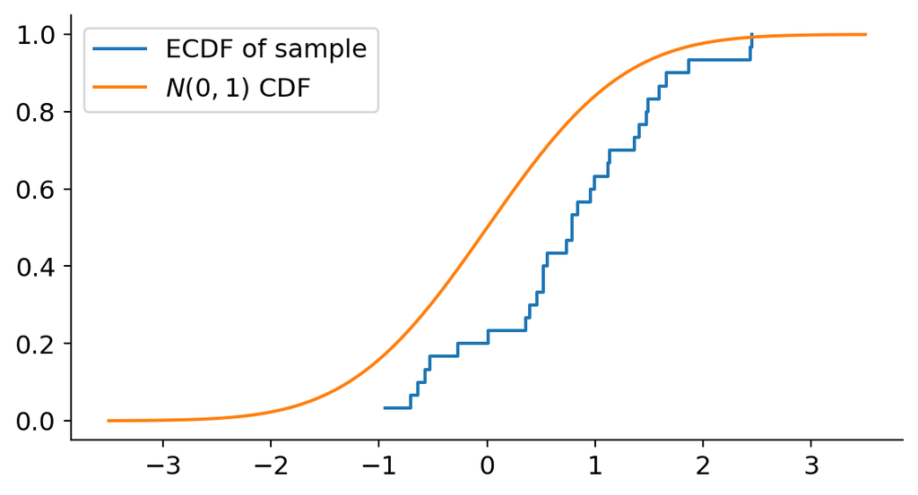

- The ECDF lies **below** the null CDF, because the sample is shifted right.
- For a pure location shift, the gap is largest near the middle of the distribution, where the CDF is steepest.

## The two-sample test

Compare two samples directly with no hypothesized $F$:

$$D_{n,m} = \sup_x \left| F_{1,n}(x) - F_{2,m}(x) \right|$$

```
KstestResult(statistic=np.float64(0.145), pvalue=np.float64(0.6860480075289528), statistic_location=np.float64(-0.06437262729863982), statistic_sign=np.int8(1))
```

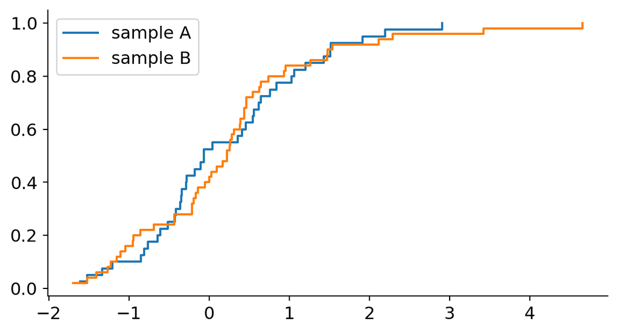

The rejection threshold uses the effective sample size $nm/(n+m)$, in place of $n$.

**References:** * [NIST Engineering Statistics Handbook §1.3.5.16](https://itl.nist.gov/div898/handbook/eda/section3/eda35g.htm) MIT OCW 18.443, Lecture 14.